# Network visualization with R

Sunbelt 2021 workshop, conducted online

Katherine Ognyanova*, [Rutgers University](http://comminfo.rutgers.edu/directory/katya/index.html)

Web*: www.kateto.net, *Twitter*: ognyanova

Download [this tutorial as a PDF file](http://kateto.net/workshops/sunbelt/sunbelt2021.pdf).

Download the [example datasets and R code](http://kateto.net/workshops/sunbelt/sunbelt2021.zip) this tutorial uses.

# 1 Introduction: network visualization

The main concern in designing a network visualization is the purpose it has to serve. What are the structural properties that we want to highlight? What are the key concerns we want to address?

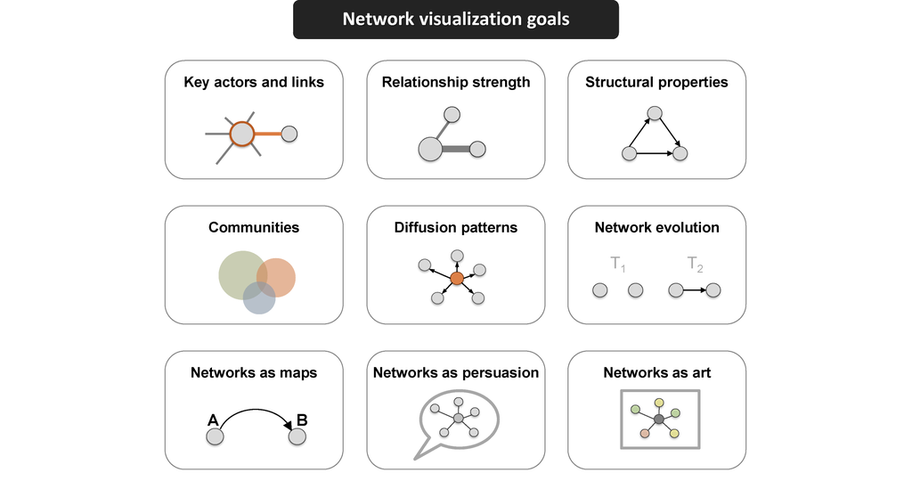

Network maps are far from the only visualization available for graphs - other network representation formats, and even simple charts of key characteristics, may be more appropriate in some cases.

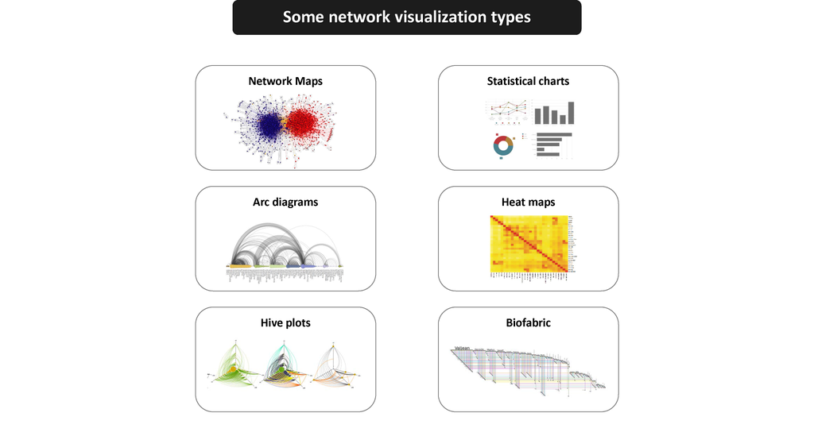

In network maps, as in other visualization formats, we have several key elements that control the outcome. The major ones are color, size, shape, and position.

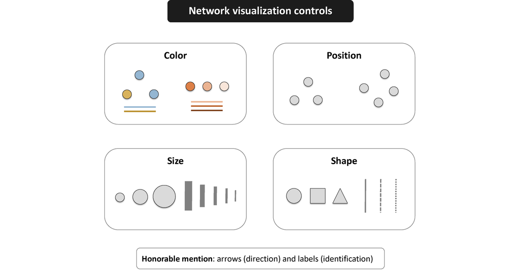

Modern graph layouts are optimized for speed and aesthetics. In particular, they seek to minimize overlaps and edge crossing, and ensure similar edge length across the graph.

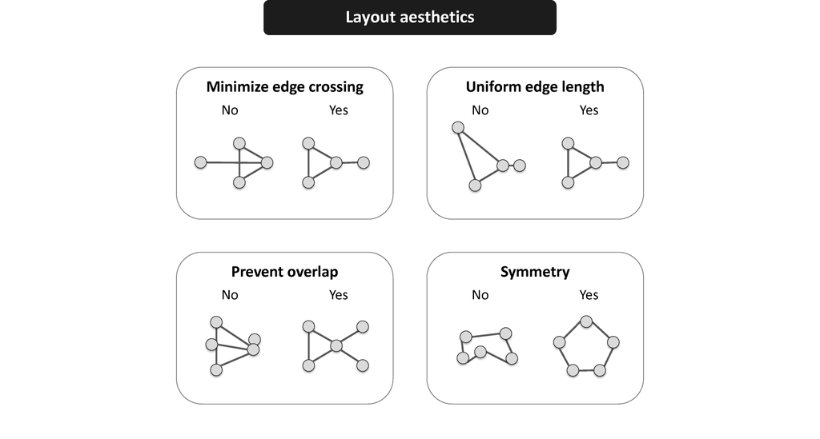

You can download all workshop materials [here](http://kateto.net/workshops/sunbelt/sunbelt2021.zip), or visit kateto.net/sunbelt2021.

This tutorial uses several key packages that you will need to install in order to follow along. Other packages will be mentioned along the way, but those are not critical and can be skipped.

The main packages we are going to use are [igraph](http://igraph.org) (maintained by [Gabor Csardi](https://github.com/gaborcsardi) and [Tamas Nepusz](https://github.com/ntamas), [sna](http://cran.r-project.org/web/packages/sna/) & [network](http://cran.r-project.org/web/packages/network/) (maintained by [Carter Butts](https://engineering.uci.edu/users/carter-butts) and the [Statnet team](http://statnet.org/)), [ggraph](http://cran.r-project.org/web/packages/ggraph/index.html) (maintained by [Thomas Lin Pederson](https://www.data-imaginist.com/)), [visNetwork](https://datastorm-open.github.io/visNetwork/) (maintained by [Benoit Thieurmel](http://www.datastorm.fr/)), [threejs](https://bwlewis.github.io/rthreejs/) (maintained by [Bryan W. Lewis](http://illposed.net/)), [NetworkD3](https://christophergandrud.github.io/networkD3/) (maintained by [Christopher Gandrud](http://christophergandrud.blogspot.com/)), and [ndtv](http://cran.r-project.org/web/packages/ndtv/) (maintained by [Skye Bender-deMoll](http://skyeome.net/wordpress/)).

```r
install.packages("igraph")
install.packages("network")
install.packages("sna")
install.packages("ggraph")
install.packages("visNetwork")
install.packages("threejs")
install.packages("networkD3")
install.packages("ndtv")
```

# 2 Colors in R plots

Colors are pretty, but more importantly, they help people differentiate between types of objects or levels of an attribute. In most R functions, you can use *named colors*, *hex*, or *RGB* values.

In the simple base R plot chart below, `x` and `y` are the point coordinates, `pch` is the point symbol shape, `cex` is the point size, and `col` is the color. To see the parameters for plotting in base R, check out `?par`.

[figure not shown]

```r
plot(x=1:10, y=rep(5,10), pch=19, cex=3, col="dark red")
points(x=1:10, y=rep(6, 10), pch=19, cex=3, col="557799")
points(x=1:10, y=rep(4, 10), pch=19, cex=3, col=rgb(.25, .5, .3))
```

You may notice that RGB here ranges from 0 to 1. While this is the R default, you can also set it to the 0-255 range using something like `rgb(10, 100, 100, maxColorValue=255)`.

We can set the opacity/transparency of an element using the parameter `alpha` (range 0-1):

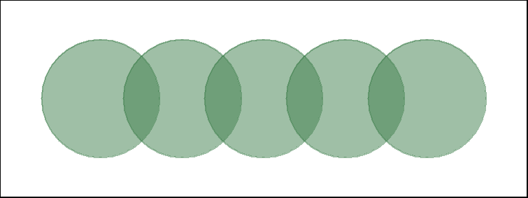

```r
plot(x=1:5, y=rep(5,5), pch=19, cex=12, col=rgb(.25, .5, .3, alpha=.5), xlim=c(0,6))
```

If we have a hex color representation, we can set the transparency alpha using `adjustcolor` from package `grDevices`. For fun, let’s also set the plot background to gray using the `par()` function for graphical parameters. We won’t do that below, but we could set the margins of the plot with `par(mar=c(bottom, left, top, right))`, or tell R not to clear the previous plot before adding a new one with `par(new=TRUE)`.

[figure not shown]

```r
par(bg="gray40")
col.tr <- grDevices::adjustcolor("557799", alpha=0.7)
plot(x=1:5, y=rep(5,5), pch=19, cex=12, col=col.tr, xlim=c(0,6))
```

If you plan on using the built-in color names, here’s how to list all of them:

```r
colors()                          # List all named colors
grep("blue", colors(), value=T)   # Colors that have "blue" in the name
```

In many cases, we need a number of contrasting colors, or multiple shades of a color. R comes with some predefined palette function that can generate those for us. For example:

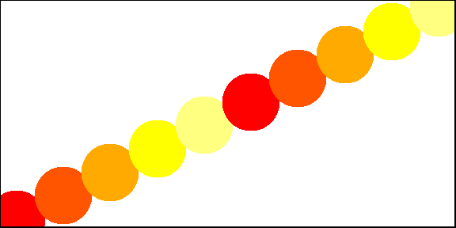

```r
pal1 <- heat.colors(5, alpha=1)   #  5 colors from the heat palette, opaque
pal2 <- rainbow(5, alpha=.5)      #  5 colors from the heat palette, transparent
plot(x=1:10, y=1:10, pch=19, cex=5, col=pal1)
```

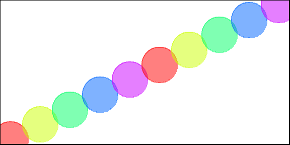

```r
plot(x=1:10, y=1:10, pch=19, cex=5, col=pal2)
```

We can also generate our own gradients using `colorRampPalette`. Note that `colorRampPalette` returns a *function* that we can use to generate as many colors from that palette as we need.

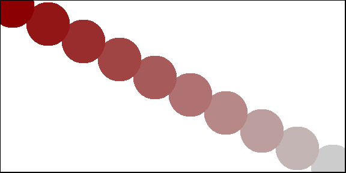

```r
palf <- colorRampPalette(c("gray80", "dark red"))
plot(x=10:1, y=1:10, pch=19, cex=5, col=palf(10))
```

To add transparency to colorRampPalette, you need to use a parameter `alpha=TRUE`:

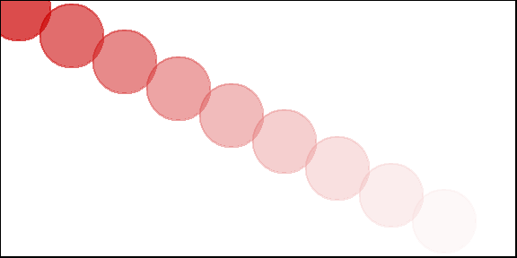

```r
palf <- colorRampPalette(c(rgb(1,1,1, .2),rgb(.8,0,0, .7)), alpha=TRUE)
plot(x=10:1, y=1:10, pch=19, cex=5, col=palf(10))
```

# 3 Data format, size, and preparation

In this tutorial, we will work primarily with two small example data sets. Both contain data about media organizations. One involves a network of hyperlinks and mentions among news sources. The second is a network of links between media venues and consumers.

While the example data used here is small, many of the ideas behind the visualizations we will generate apply to medium and large-scale networks. This is also the reason why we will rarely use certain visual properties such as the shape of the node symbols: those are impossible to distinguish in larger graph maps. In fact, when drawing very big networks we may even want to hide the network edges, and focus on identifying and visualizing communities of nodes.

At this point, the size of the networks you can visualize in R is limited mainly by the RAM of your machine. One thing to emphasize though is that in many cases, visualizing larger networks as giant hairballs is less helpful than providing charts that show key characteristics of the graph.

## 3.1 *DATASET 1: edgelist*

The first data set we are going to work with consists of two files, *“Dataset1-Media-Example-NODES.csv”* and *“Dataset1-Media-Example-EDGES.csv”* ([download here](http://kateto.net/workshops/sunbelt/sunbelt2021.zip)).

```r
nodes <- read.csv("Dataset1-Media-Example-NODES.csv", header=T, as.is=T)
links <- read.csv("Dataset1-Media-Example-EDGES.csv", header=T, as.is=T)
```

Examine the data:

```r
head(nodes)
head(links)
```

## 3.2 *Creating an igraph object*

Next we will convert the raw data to an [igraph](http://igraph.org/) network object. To do that, we will use the `graph_from_data_frame()` function, which takes two data frames: `d` and `vertices`.

- **d** describes the edges of the network. Its first two columns are the IDs of the source and the target node for each edge. The following columns are edge attributes (weight, type, label, or anything else).
- **vertices** starts with a column of node IDs. Any following columns are interpreted as node attributes.

```r
library('igraph')
net <- graph_from_data_frame(d=links, vertices=nodes, directed=T)
net
```

```
## IGRAPH cd9639c DNW- 17 49 --
## + attr: name (v/c), media (v/c), media.type (v/n), type.label (v/c),
## | audience.size (v/n), type (e/c), weight (e/n)
## + edges from cd9639c (vertex names):
##  [1] s01->s02 s01->s03 s01->s04 s01->s15 s02->s01 s02->s03 s02->s09 s02->s10
##  [9] s03->s01 s03->s04 s03->s05 s03->s08 s03->s10 s03->s11 s03->s12 s04->s03
## [17] s04->s06 s04->s11 s04->s12 s04->s17 s05->s01 s05->s02 s05->s09 s05->s15
## [25] s06->s06 s06->s16 s06->s17 s07->s03 s07->s08 s07->s10 s07->s14 s08->s03
## [33] s08->s07 s08->s09 s09->s10 s10->s03 s12->s06 s12->s13 s12->s14 s13->s12
## [41] s13->s17 s14->s11 s14->s13 s15->s01 s15->s04 s15->s06 s16->s06 s16->s17
## [49] s17->s04
```

The description of an [igraph](http://igraph.org/) object starts with four letters:

1. D or U, for a directed or undirected graph
2. N for a named graph (where nodes have a `name` attribute)
3. W for a weighted graph (where edges have a `weight` attribute)
4. B for a bipartite (two-mode) graph (where nodes have a `type` attribute)

The two numbers that follow (17 49) refer to the number of nodes and edges in the graph. The description also lists node & edge attributes, for example:

- `(g/c)` - graph-level character attribute
- `(v/c)` - vertex-level character attribute
- `(e/n)` - edge-level numeric attribute

We also have easy access to nodes, edges, and their attributes with:

```r
E(net)       # The edges of the "net" object
V(net)       # The vertices of the "net" object
E(net)$type  # Edge attribute "type"
V(net)$media # Vertex attribute "media"

# Find nodes and edges by attribute:
# (that returns oblects of type vertex sequence/edge sequence)
V(net)[media=="BBC"]
E(net)[type=="mention"]

# You can also examine the network matrix directly:
net[1,]
net[5,7]
```

It is also easy to extract an edge list or matrix back from the `igraph` network:

```r
# Get an edge list or a matrix:
as_edgelist(net, names=T)
as_adjacency_matrix(net, attr="weight")

# Or data frames describing nodes and edges:
as_data_frame(net, what="edges")
as_data_frame(net, what="vertices")
```

Now that we have our igraph network object, let’s make a first attempt to plot it.

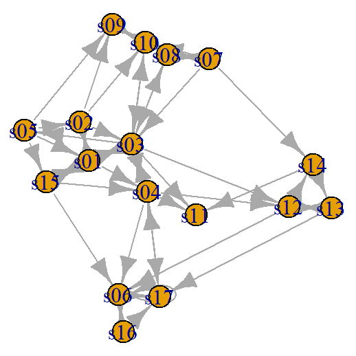

```r
plot(net) # not a pretty picture!
```

That doesn’t look very good. Let’s start fixing things by removing the loops in the graph.

```r
net <- simplify(net, remove.multiple = F, remove.loops = T)
```

We could also use `simplify` to combine multiple edges by summing their weights with a command like `simplify(net, edge.attr.comb=list(Weight="sum","ignore"))`. Note, however, that this would also combine multiple edge types (in our data: “hyperlinks” and “mentions”).

Let’s and reduce the arrow size and remove the labels (we do that by setting them to `NA`):

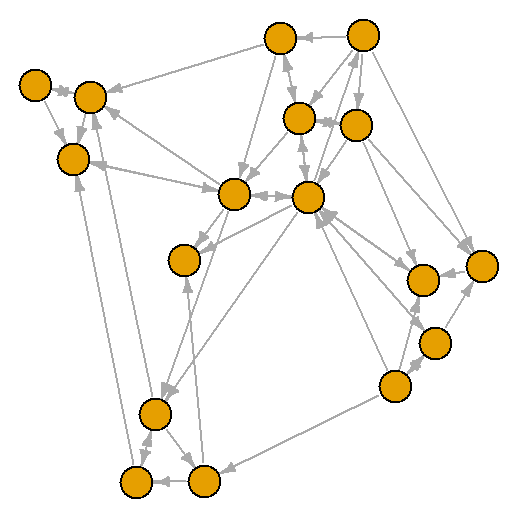

```r
plot(net, edge.arrow.size=.4,vertex.label=NA)
```

## 3.3 *DATASET 2: matrix*

```r
nodes2 <- read.csv("Dataset2-Media-User-Example-NODES.csv", header=T, as.is=T)
links2 <- read.csv("Dataset2-Media-User-Example-EDGES.csv", header=T, row.names=1)
```

Examine the data:

```r
head(nodes2)
head(links2)
```

## 3.4 *Two-mode (bipartite) networks in igraph*

Next we will convert our second network into an igraph object.

We can see that `links2` is an adjacency matrix for a two-mode network. Two-mode or bipartite graphs have two different types of actors and links that go across, but not within each type. Our second media example is a network of that kind, examining links between news sources and their consumers.

```r
links2 <- as.matrix(links2)
dim(links2)
dim(nodes2)
```

As we have seen above, the edges of our second network are in a matrix format. We can read those into a graph object using `graph_from_incidence_matrix()`. In igraph, bipartite networks have a node attribute called `type` that is `FALSE` (or 0) for vertices in one mode and `TRUE` (or 1) for those in the other mode.

```r
head(nodes2)
head(links2)

net2 <- graph_from_incidence_matrix(links2)
table(V(net2)$type)
```

To transform a one-mode network matrix into an `igraph` object, use `graph_from_adjacency_matrix()`.

# 4 Plotting networks with *igraph*

## 4.1 *Plotting parameters*

Plotting with `igraph`: the network plots have a wide set of parameters you can set. Those include node options (starting with `vertex.`) and edge options (starting with `edge.`). A list of selected options is included below, but you can also check out `?igraph.plotting` for more information.

The igraph plotting parameters include (among others):

| **NODES** |  |
| --- | --- |
| **vertex.color** | Node color |
| **vertex.frame.color** | Node border color |
| **vertex.shape** | One of “none”, “circle”, “square”, “csquare”, “rectangle” “crectangle”, “vrectangle”, “pie”, “raster”, or “sphere” |
| **vertex.size** | Size of the node (default is 15) |
| **vertex.size2** | The second size of the node (e.g. for a rectangle) |
| **vertex.label** | Character vector used to label the nodes |
| **vertex.label.family** | Font family of the label (e.g.“Times”, “Helvetica”) |
| **vertex.label.font** | Font: 1 plain, 2 bold, 3, italic, 4 bold italic, 5 symbol |
| **vertex.label.cex** | Font size (multiplication factor, device-dependent) |
| **vertex.label.dist** | Distance between the label and the vertex |
| **vertex.label.degree** | The position of the label in relation to the vertex, where 0 is right, “pi” is left, “pi/2” is below, and “-pi/2” is above |
| **EDGES** |  |
| **edge.color** | Edge color |
| **edge.width** | Edge width, defaults to 1 |
| **edge.arrow.size** | Arrow size, defaults to 1 |
| **edge.arrow.width** | Arrow width, defaults to 1 |
| **edge.lty** | Line type, could be 0 or “blank”, 1 or “solid”, 2 or “dashed”, 3 or “dotted”, 4 or “dotdash”, 5 or “longdash”, 6 or “twodash” |
| **edge.label** | Character vector used to label edges |
| **edge.label.family** | Font family of the label (e.g.“Times”, “Helvetica”) |
| **edge.label.font** | Font: 1 plain, 2 bold, 3, italic, 4 bold italic, 5 symbol |
| **edge.label.cex** | Font size for edge labels |
| **edge.curved** | Edge curvature, range 0-1 (FALSE sets it to 0, TRUE to 0.5) |
| **arrow.mode** | Vector specifying whether edges should have arrows, possible values: 0 no arrow, 1 back, 2 forward, 3 both |
| **OTHER** |  |
| **margin** | Empty space margins around the plot, vector with length 4 |
| **frame** | if TRUE, the plot will be framed |
| **main** | If set, adds a title to the plot |
| **sub** | If set, adds a subtitle to the plot |
| **asp** | Numeric, the aspect ratio of a plot (y/x). |
| **palette** | A color palette to use for vertex color |
| **rescale** | Whether to rescale coordinates to [-1,1]. Default is TRUE. |

We can set the node & edge options in two ways - the first one is to specify them in the `plot()` function, as we are doing below.

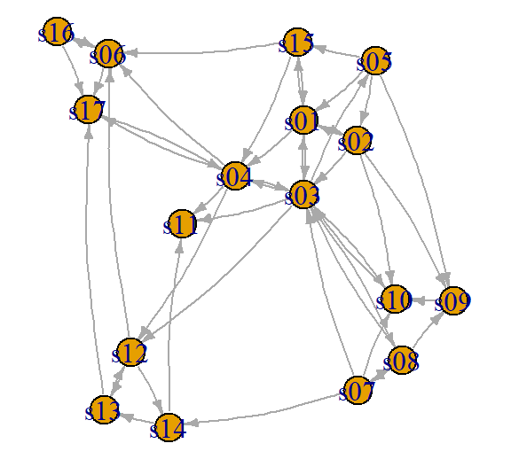

```r
# Plot with curved edges (edge.curved=.1) and reduce arrow size:
# Note that using curved edges will allow you to see multiple links
# between two nodes (e.g. links going in either direction, or multiplex links)
plot(net, edge.arrow.size=.4, edge.curved=.1)
```

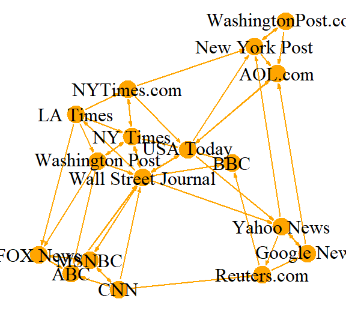

```r
# Set edge color to light gray, the node & border color to orange
# Replace the vertex label with the node names stored in "media"
plot(net, edge.arrow.size=.2, edge.color="orange",
     vertex.color="orange", vertex.frame.color="#ffffff",
     vertex.label=V(net)$media, vertex.label.color="black")
```

The second way to set attributes is to add them to the `igraph` object. Let’s say we want to color our network nodes based on type of media, and size them based on degree centrality (more links -> larger node) We will also change the width of the edges based on their weight.

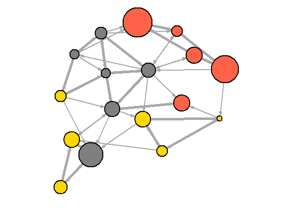

```r
# Generate colors based on media type:
colrs <- c("gray50", "tomato", "gold")
V(net)$color <- colrs[V(net)$media.type]

# Compute node degrees (#links) and use that to set node size:
deg <- degree(net, mode="all")
V(net)$size <- deg*3
# We could also use the audience size value:
V(net)$size <- V(net)$audience.size*0.6

# The labels are currently node IDs.
# Setting them to NA will render no labels:
V(net)$label <- NA

# Set edge width based on weight:
E(net)$width <- E(net)$weight/6

#change arrow size and edge color:
E(net)$arrow.size <- .2
E(net)$edge.color <- "gray80"

# We can even set the network layout:
graph_attr(net, "layout") <- layout_with_lgl
plot(net)
```

We can also override the attributes explicitly in the plot:

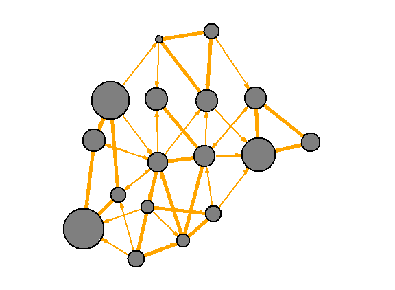

```r
plot(net, edge.color="orange", vertex.color="gray50")
```

It helps to add a legend explaining the meaning of the colors we used:

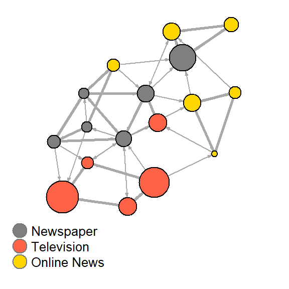

```r
plot(net)
legend(x=-1.5, y=-1.1, c("Newspaper","Television", "Online News"), pch=21,
       col="#777777", pt.bg=colrs, pt.cex=2, cex=.8, bty="n", ncol=1)
```

Sometimes, especially with semantic networks, we may be interested in plotting only the labels of the nodes:

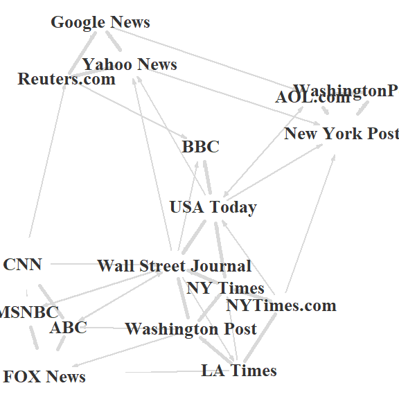

```r
plot(net, vertex.shape="none", vertex.label=V(net)$media,
     vertex.label.font=2, vertex.label.color="gray40",
     vertex.label.cex=.7, edge.color="gray85")
```

Let’s color the edges of the graph based on their source node color. We can get the starting node for each edge with the `ends()` igraph function. It returns the start and end vertex for edges listed in the `es` parameter. The `names` parameter control whether the function returns edge names or IDs.

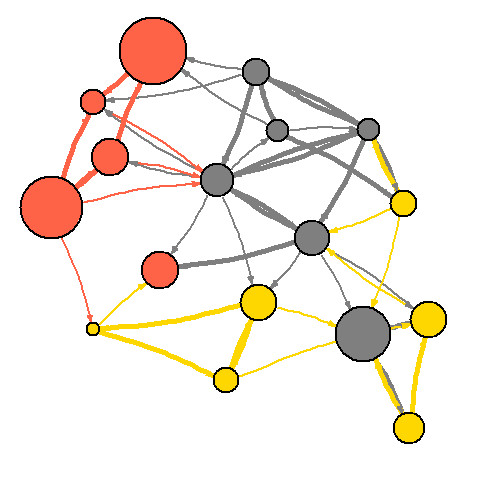

```r
edge.start <- ends(net, es=E(net), names=F)[,1]
edge.col <- V(net)$color[edge.start]

plot(net, edge.color=edge.col, edge.curved=.1)
```

## 4.2 *Network layouts*

Network layouts are simply algorithms that return coordinates for each node in a network.

For the purposes of exploring layouts, we will generate a slightly larger 100-node graph. We use the `sample_pa()` function which generates a simple graph starting from one node and adding more nodes and links based on a preset level of preferential attachment (Barabasi-Albert model).

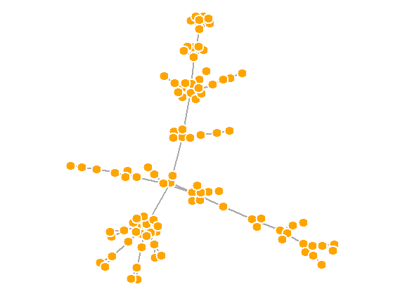

```r
net.bg <- sample_pa(100)
V(net.bg)$size <- 8
V(net.bg)$frame.color <- "white"
V(net.bg)$color <- "orange"
V(net.bg)$label <- ""
E(net.bg)$arrow.mode <- 0
plot(net.bg)
```

You can set the layout in the plot function:

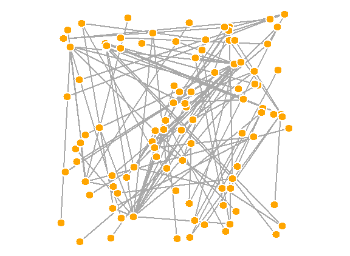

```r
plot(net.bg, layout=layout_randomly)
```

Or you can calculate the vertex coordinates in advance:

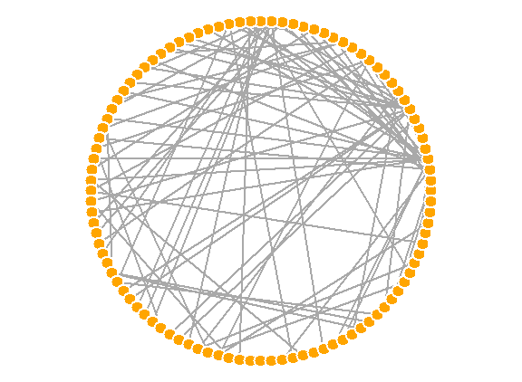

```r
l <- layout_in_circle(net.bg)
plot(net.bg, layout=l)
```

`l` is simply a matrix of x, y coordinates (N x 2) for the N nodes in the graph. For 3D layouts, it has x, y, and z coordinates (N x 3). You can easily generate your own:

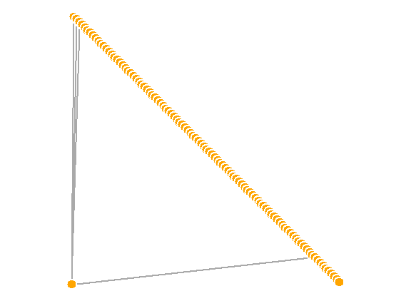

```r
l <- cbind(1:vcount(net.bg), c(1, vcount(net.bg):2))
plot(net.bg, layout=l)
```

This layout is just an example and not very helpful - thankfully igraph has a number of built-in layouts, including:

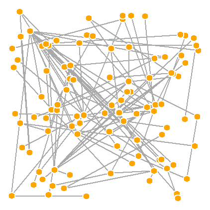

```r
# Randomly placed vertices
l <- layout_randomly(net.bg)
plot(net.bg, layout=l)
```

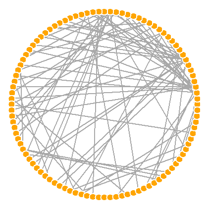

```r
# Circle layout
l <- layout_in_circle(net.bg)
plot(net.bg, layout=l)
```

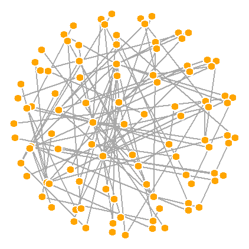

```r
# 3D sphere layout
l <- layout_on_sphere(net.bg)
plot(net.bg, layout=l)
```

Fruchterman-Reingold is one of the most used force-directed layout algorithms out there.